# Week 6

Daniel Gonzalez-Suarez

3/3/2020

# Introduction

Here we will explore how to create basic plots in R. To acknowledge my forebears, much of the material on this week’s class is based on a course in R by Dr. Brett Favaro.

Read the file WhitefishLS.csv into R These data are derived from Derek Ogle’s FSA data resources: http://derekogle.com/fishR/data/data-html/WhitefishLS.html

> > > Whitefish example, Variables are: year: Year of catch. state: State of catch (MI, MN, or WI). catch: Catch in lbs. value: Value of catch in dollars.

# Install required packages

```r
# If you don't yet have tidyverse run:
# install.packages("tidyverse")
library(tidyverse)

# We will require this package to handle some dates in this dataset
# install.packages("lubridate")
library(lubridate)
```

#Load data: Remember to check if it loaded & if data types are correct

```r
whitefish <- read.csv("./data/WhitefishLS.csv")

# ------------------------------------------
#STEP 1: Did it load correctly?
  head(whitefish)
```

```
##   year state  catch  value
## 1 1971    MI 447564 229001
## 2 1971    WI 264009 110540
## 3 1972    MI 455631 250860
## 4 1972    WI 277295 133918
## 5 1973    MI 501436 301909
## 6 1973    MN   3064   1568
```

```r
# ------------------------------------------
#STEP 2: Are the data types right?
  sapply(whitefish, class)
```

```
##      year     state     catch     value
## "integer"  "factor" "integer" "integer"
```

```r
#appears fine, except we have a date-type variable here.

# We will use the lubridate::date_decimal
# It tells R this is a date not a number
whitefish$year <- date_decimal(whitefish$year)

sapply(whitefish, class)
```

```
## $year
## [1] "POSIXct" "POSIXt"
##
## $state
## [1] "factor"
##
## $catch
## [1] "integer"
##
## $value
## [1] "integer"
```

```r
# We will explore some other functions of lubridate later

# ------------------------------------------
# STEP 3: Check for missing or impossible values

range(whitefish$year) #It now lines up with http://derekogle.com/fishR/data/data-html/WhitefishLS.html
```

```
## [1] "1971-01-01 UTC" "2001-01-01 UTC"
```

```r
range(whitefish$catch) #nothing jumps out as wrong. I guess it's a big fishery
```

```
## [1]       2 1890271
```

```r
plot(whitefish$catch)
```

```r
range(whitefish$value) #nothing impossible
```

```
## [1]       0 1748145
```

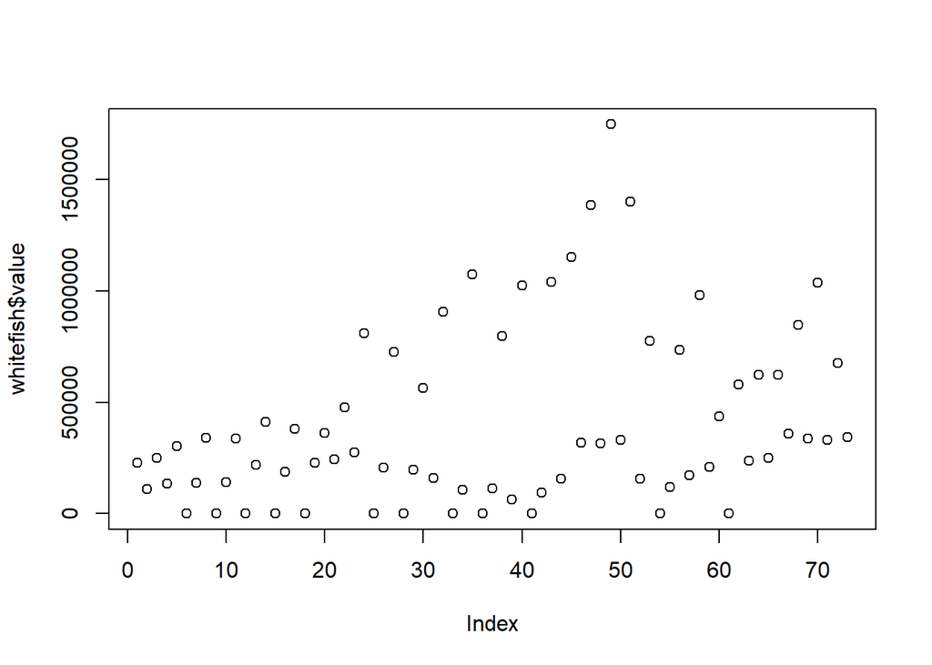

```r
plot(whitefish$value)
```

```r
# ------------------------------------------
# STEP 4: Factor levels

levels(whitefish$state)
```

```
## [1] "MI" "MN" "WI"
```

```r
# All seems to be OK!

# Let's move on to plotting!
```

# Plot One Variable - Base

```r
plot(whitefish$catch ~ whitefish$state)
```

```r
# One variable, X = Discrete (states)
# Y can only be count (catch)

table(whitefish$state)
```

```
##
## MI MN WI
## 31 11 31
```

```r
#Here 'table' creates a contingency table of the counts of each factor in a specific variable, in this case the number of times a state is mentioned
?table
```

```
## starting httpd help server ... done
```

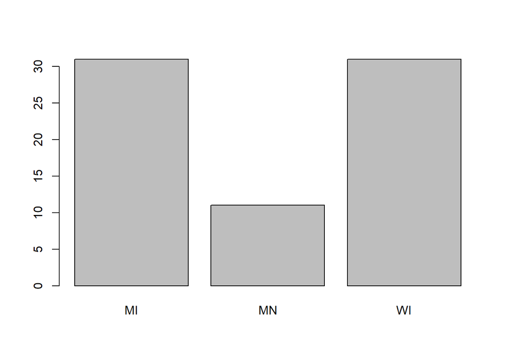

```r
barplot(table(whitefish$state))
```

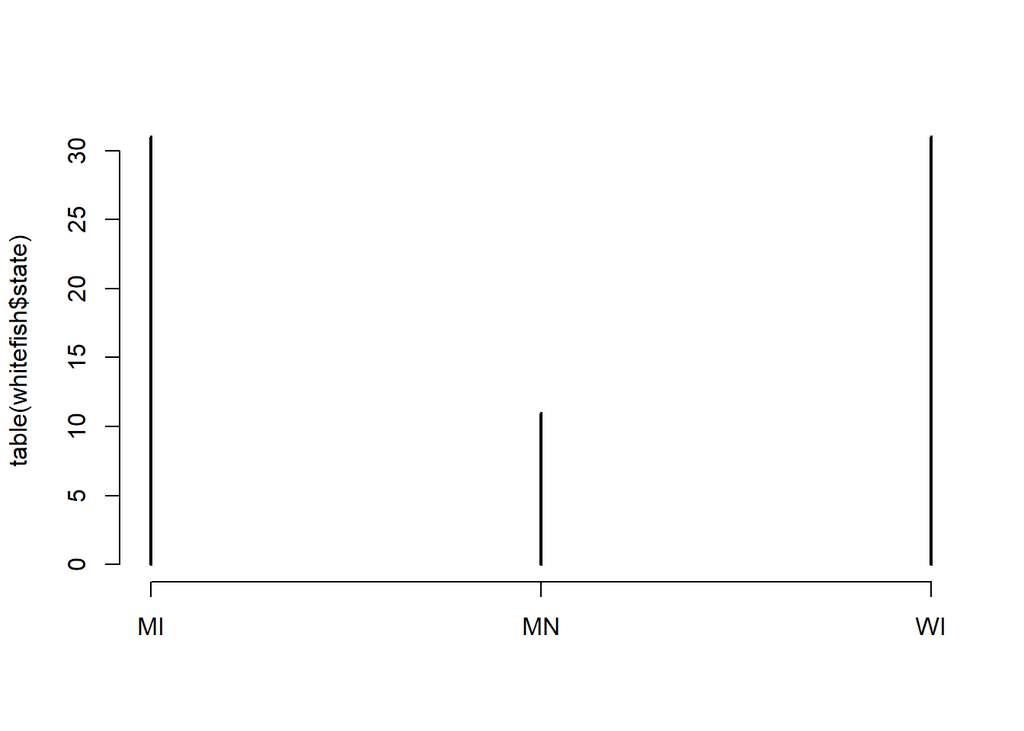

```r
plot(table(whitefish$state))
```

```r
# PLOT ONE VARIABLE
# Continuous X

plot(whitefish$catch)
```

```r
# No, this does not work

hist(whitefish$catch)
# Yes, this looks much better

?hist

# We can chose different breaks or bins of data
hist(whitefish$catch, breaks=10)
```

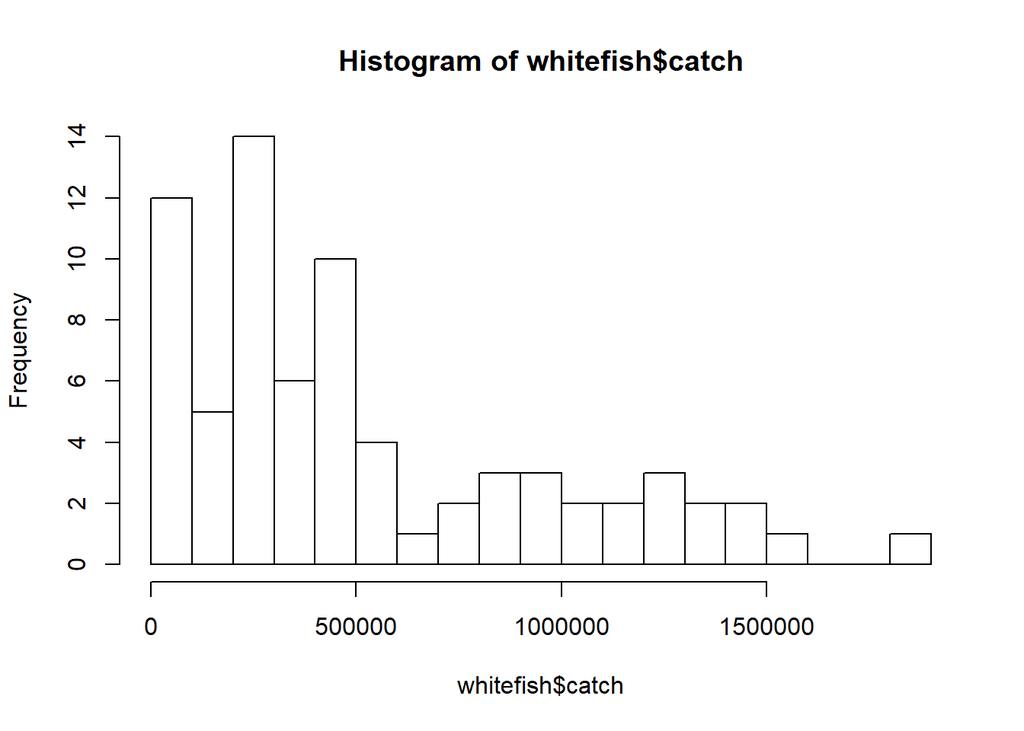

```r
hist(whitefish$catch, breaks=20)
```

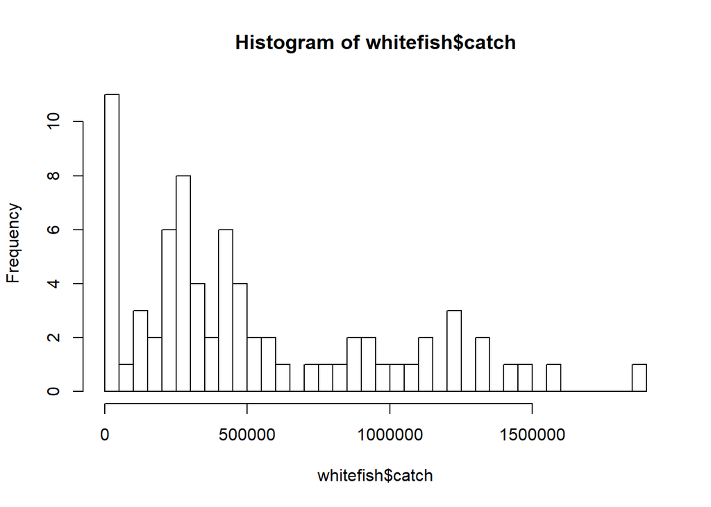

```r
hist(whitefish$catch, breaks=30)
```

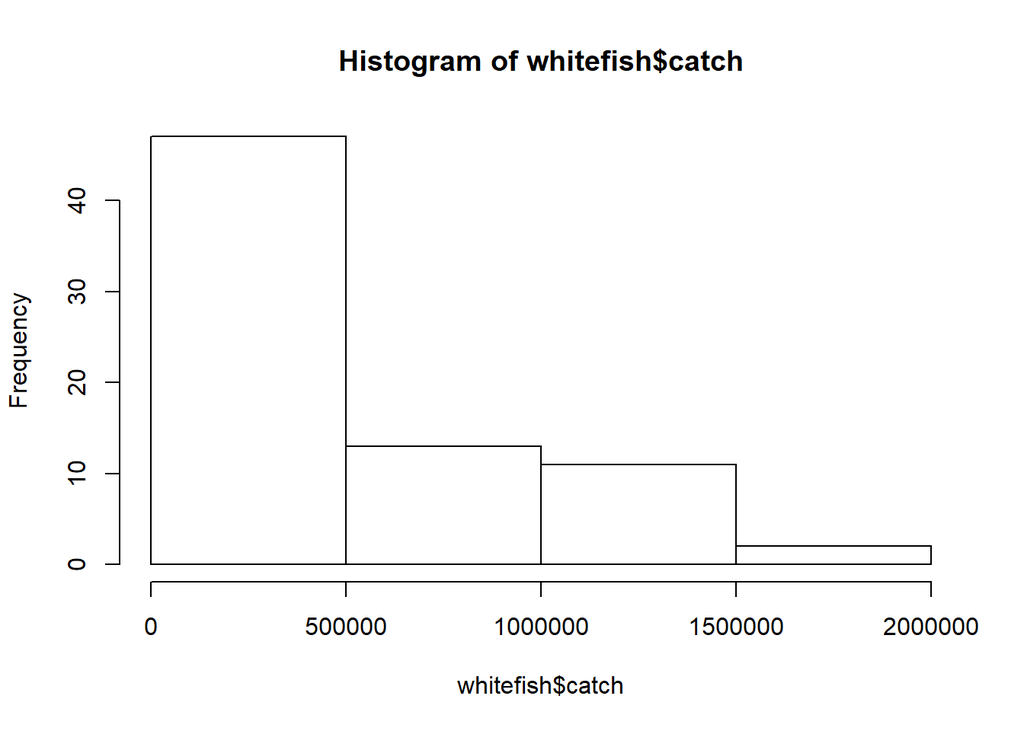

```r
# Or assign them mannually
hist(whitefish$catch, breaks=c(0,500000,1000000,1500000, 2000000))
```

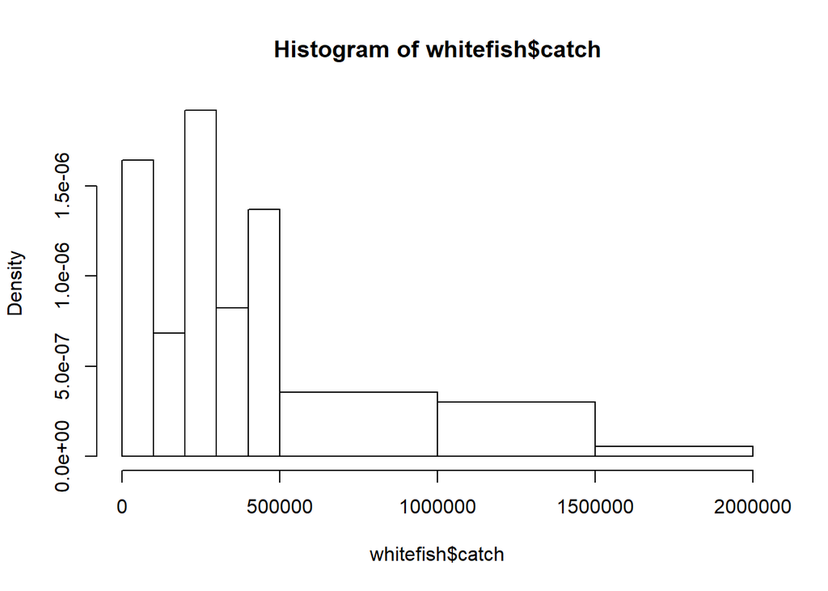

```r
hist(whitefish$catch, breaks=c(0,100000,200000,300000,400000,500000,1000000,1500000,2000000))
```

```r
# Many calculations are conducted by the hist function prior to plotting
# and you can extract those values
histinfo <- hist(whitefish$catch)
```

```r
histinfo
```

```
## $breaks
##  [1]       0  200000  400000  600000  800000 1000000 1200000 1400000 1600000
## [10] 1800000 2000000
##
## $counts
##  [1] 17 20 14  3  6  4  5  3  0  1
##
## $density
##  [1] 1.164384e-06 1.369863e-06 9.589041e-07 2.054795e-07 4.109589e-07
##  [6] 2.739726e-07 3.424658e-07 2.054795e-07 0.000000e+00 6.849315e-08
##
## $mids
##  [1]  100000  300000  500000  700000  900000 1100000 1300000 1500000 1700000
## [10] 1900000
##
## $xname
## [1] "whitefish$catch"
##
## $equidist
## [1] TRUE
##
## attr(,"class")
## [1] "histogram"
```

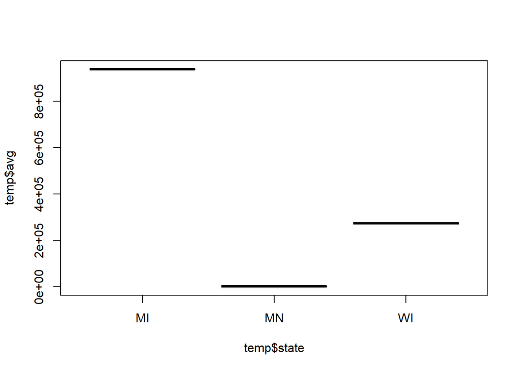

```r
# Making a point about data density... let's plot mean by state
# Remember some of dplyr functions
temp <- whitefish %>%
  group_by(state) %>%
  summarise(avg = mean(catch))

plot(temp$avg ~ temp$state)
```

```r
# It is nice to have average values, but they can mislead interpretation
# of results

# Perhaps it is better to have range of values on this one
# This can be easily achieved with boxplot
boxplot(whitefish$catch ~ whitefish$state)
# When you plot a Discrete X and continuous Y variable plot will return
# a boxplot by default
plot(whitefish$catch ~ whitefish$state)
```

# Plot One Variable - ggplot

```r
# Formulation and syntaxis is different

ggplot(data = whitefish,
       aes(state))  +
  geom_bar()
```

```r
#ggplot(data = DATA,
#       aes(WHAT YOU WANT TO PLOT)) +
#  GRAPHICAL ELEMENTS, ADDED ONE BY ONE LIKE LAYERS

a <- ggplot(data = whitefish,
       aes(state)) +
  geom_bar()

print(a) #this is necessary when in the R interface
```

```r
a #this one also works in Rstudio
```

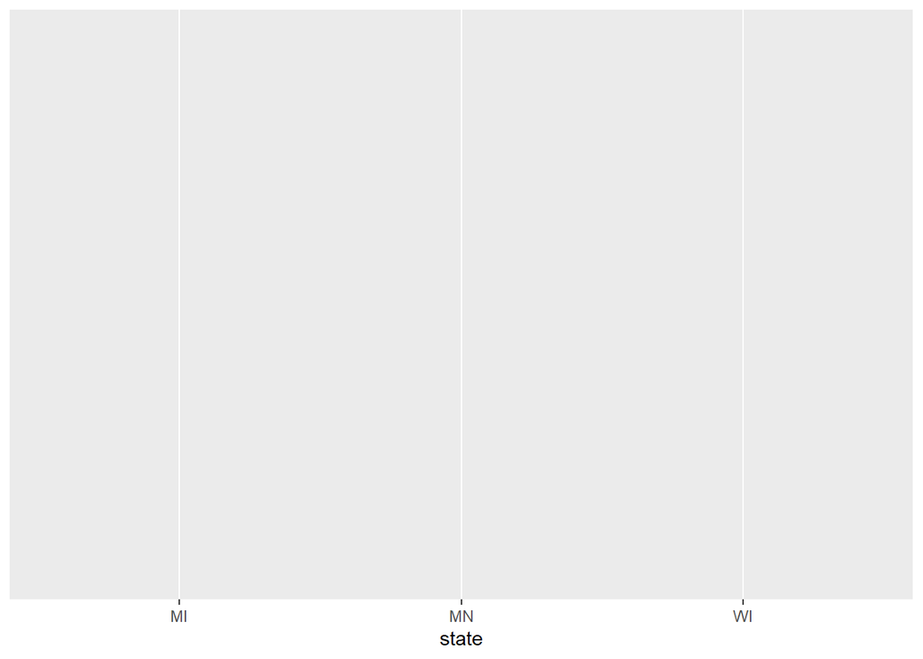

```r
# Demonstrate how things can be layered
a <- ggplot(data = whitefish,
            aes(state))

a #Here we just called the function and the discrete variable but have not assigned what will be plotted
```

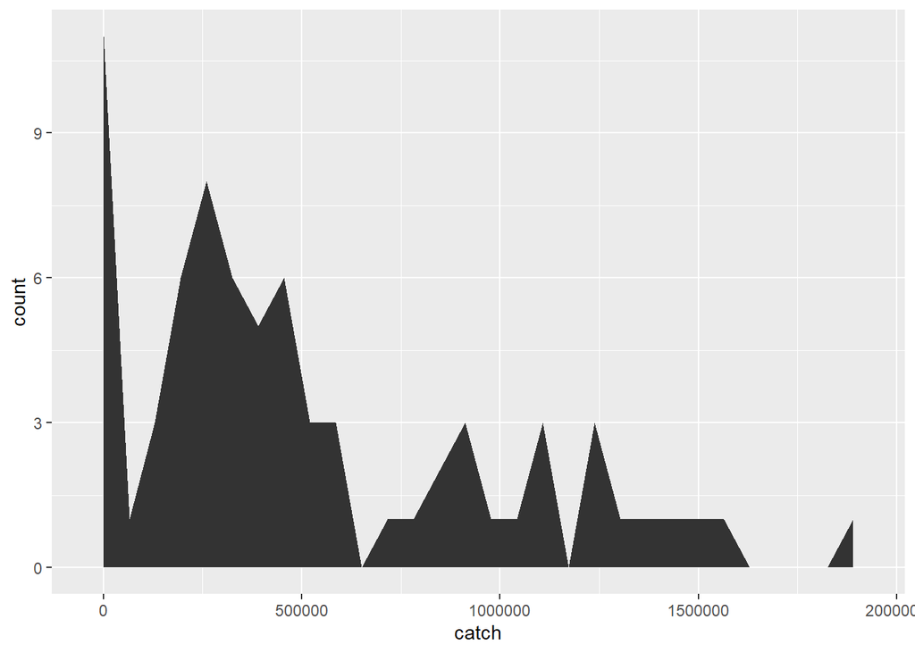

```r
# ONE VARIABLE CONTINUOUS

a <- ggplot(data=whitefish,
            aes(catch))
# OK, we want to plot catch values

a + geom_area(stat="bin") #warning just tells you that default 'bin=30'
```

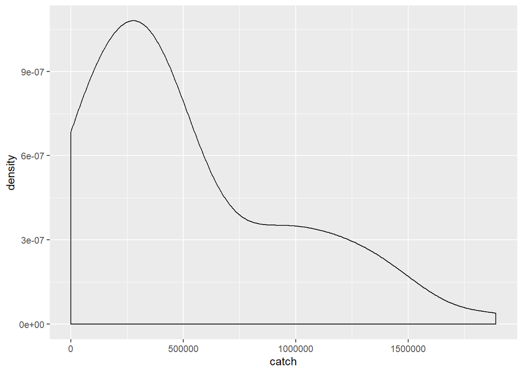

```r
a + geom_density()
```

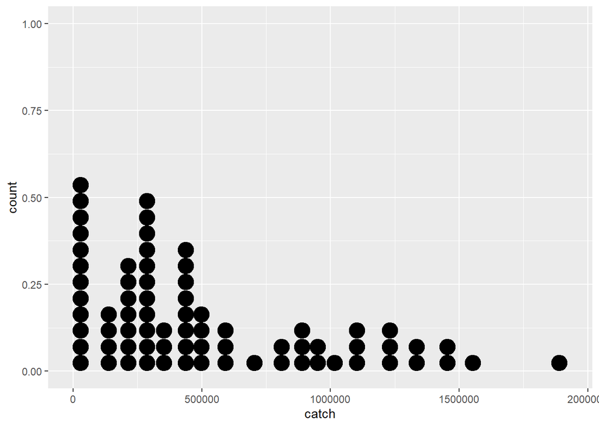

```r
a + geom_dotplot()#warning just tells you that default 'bin=30'
```

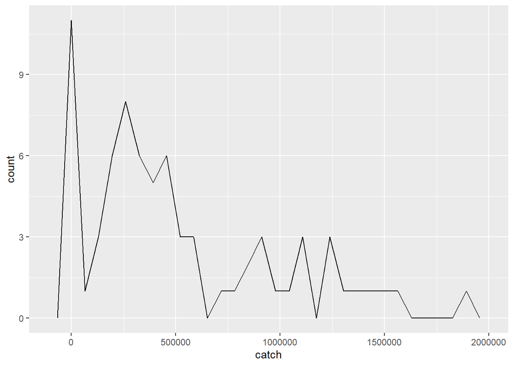

```r
a + geom_freqpoly()
```

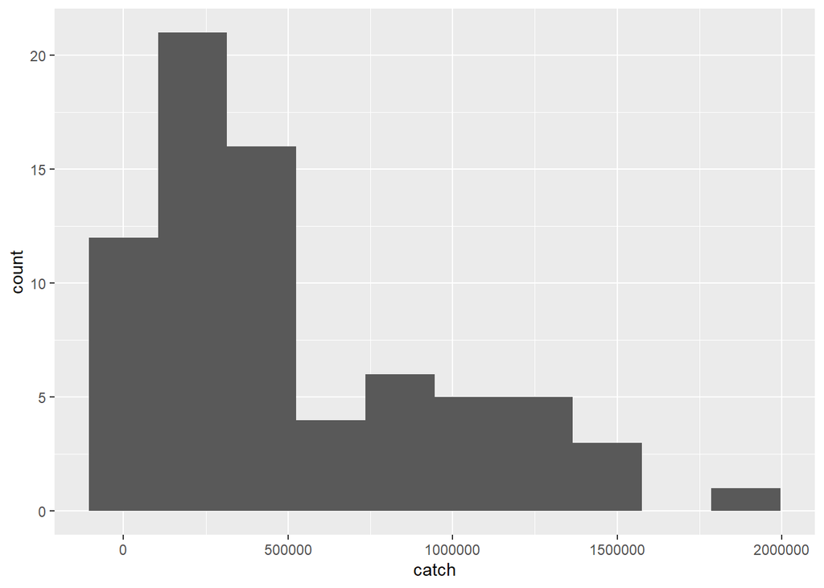

```r
a + geom_histogram() #this one is like base 'hist()'
#Let's follow the warning suggestion and explore different bin sizes
a + geom_histogram(bins=10)
```

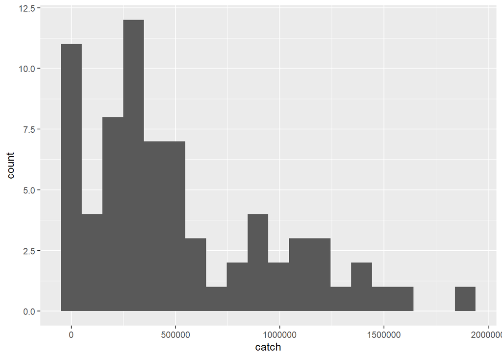

```r
a + geom_histogram(bins=20)
```

```r
a + geom_histogram(bins=30)
```

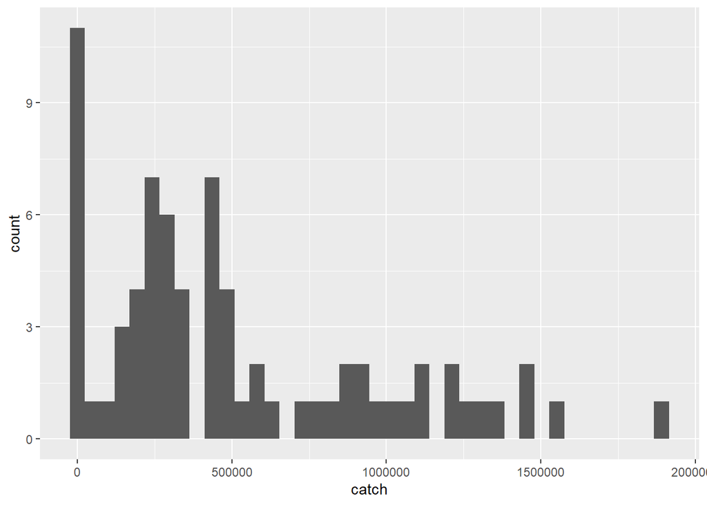

```r
a + geom_histogram(bins=40)
```

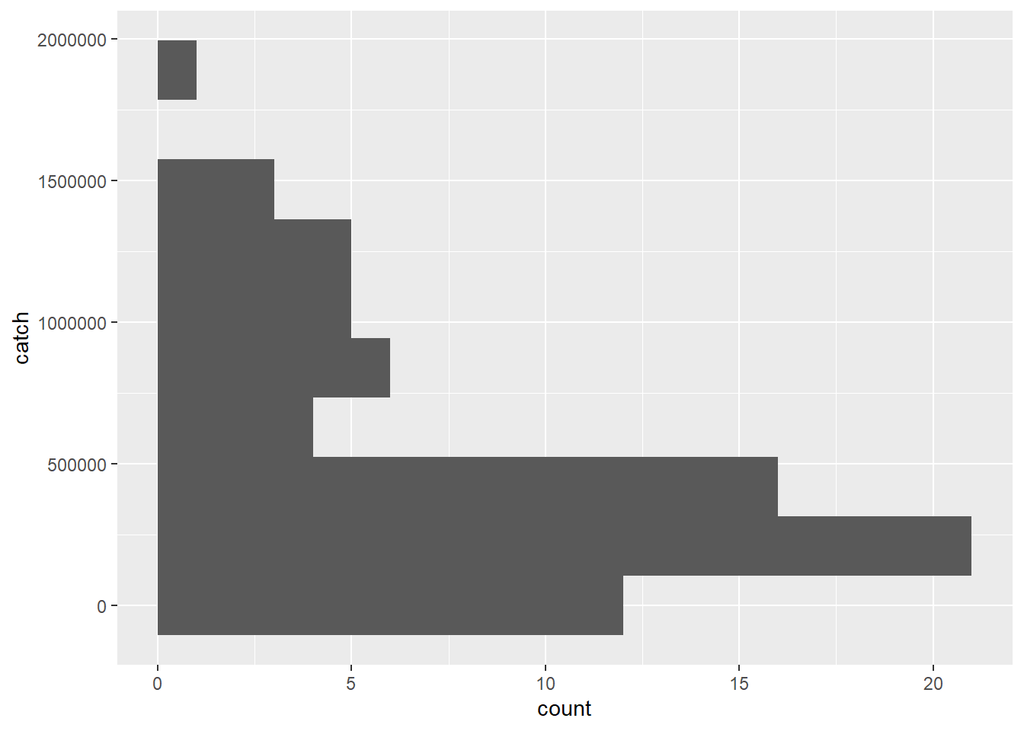

```r
a + geom_histogram(bins = 10) + coord_flip()
```

```r
#'coord_flip' flips the axis order
```

# Plot Two Variable - Base

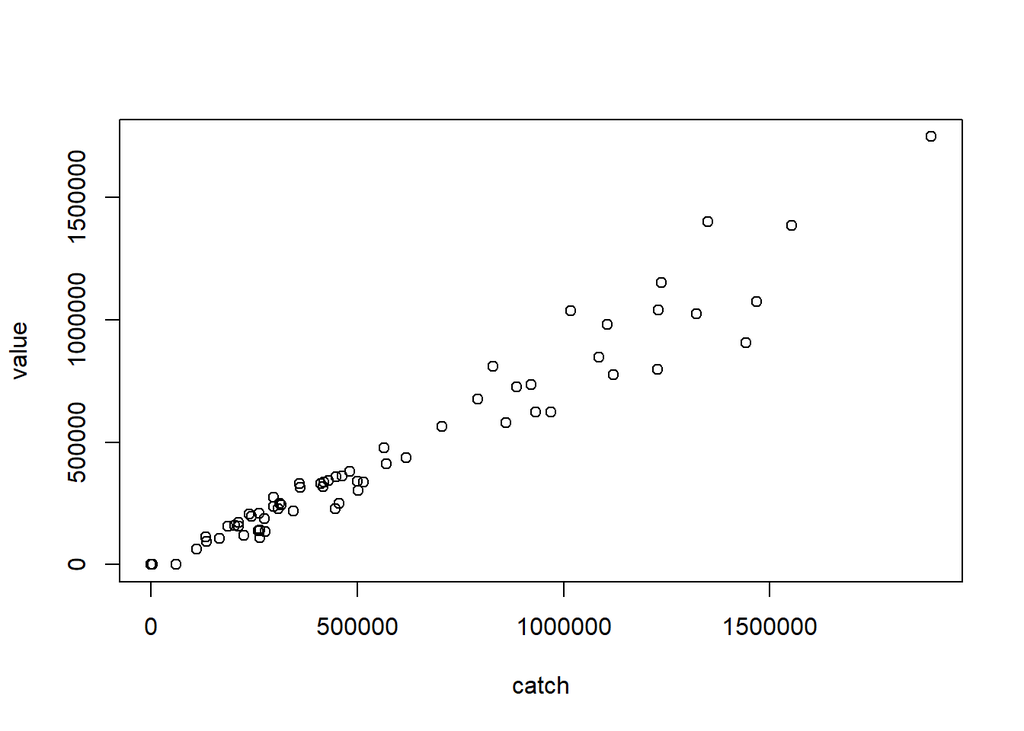

```r
plot(value ~ catch, data=whitefish)
```

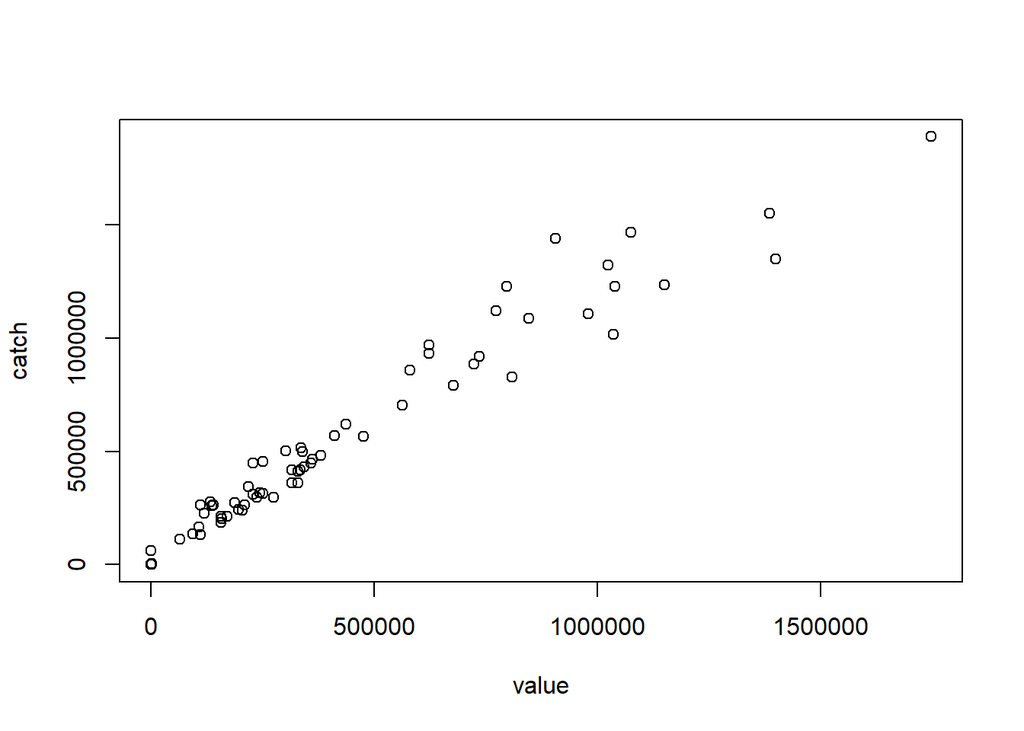

```r
plot(catch ~ value, data=whitefish)
```

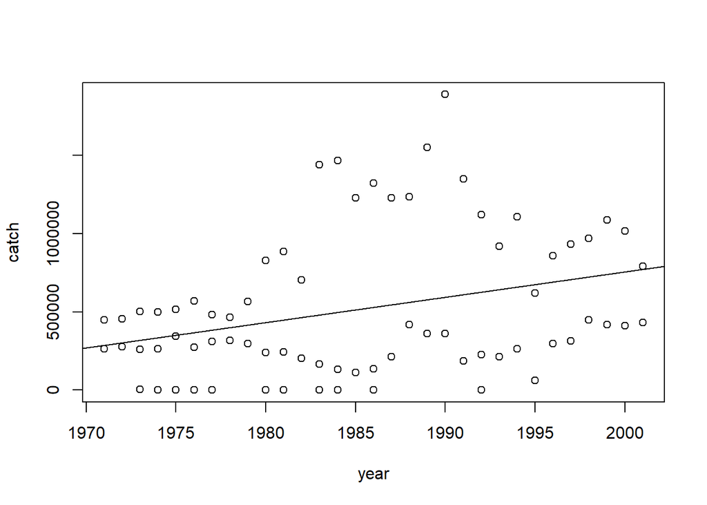

```r
# Which is the correct one? Which story do you want to tell?
# Which one makes more sense?
# Remember 'response' vs 'predictive' variables

plot(catch ~ year, data=whitefish)
# We can add lines representing linear model fits
abline(lm(catch~year, data=whitefish))
```

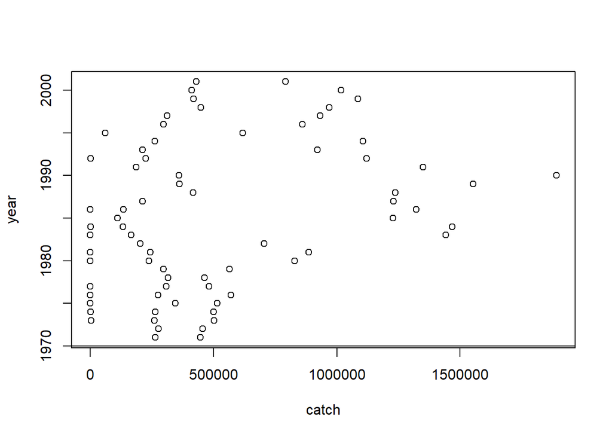

```r
plot(year ~ catch, data=whitefish)
abline(lm(catch~year, data=whitefish))
```

```r
# This won't work, it does not make sense variables in this order
```

# Plot Two Variable - ggplot

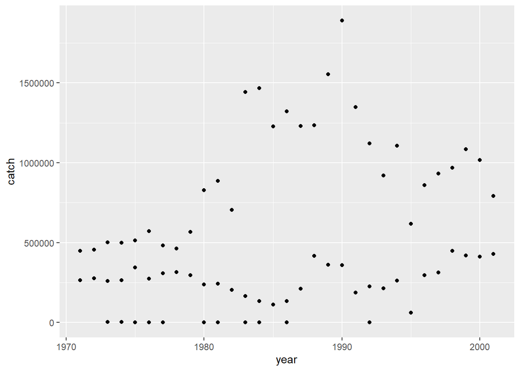

```r
# Continuous X, continuous Y

a <- ggplot(data=whitefish, aes(x = year, y = catch))
# The above creates an object where we store the 'base plot'
a + geom_point() # This adds points as a scatterplot
```

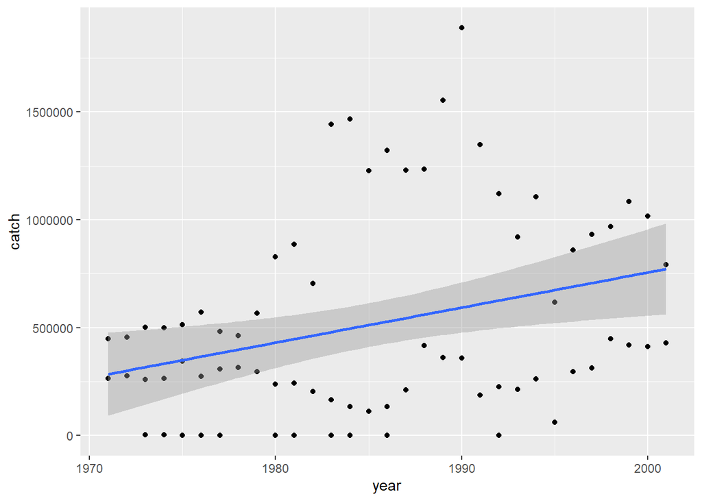

```r
a <- ggplot(data=whitefish, aes(x = year, y = catch)) +
  geom_point() +
  geom_smooth(method="lm", level=0.95) # Then add a linear model fit

a # Call to see how it looks
```

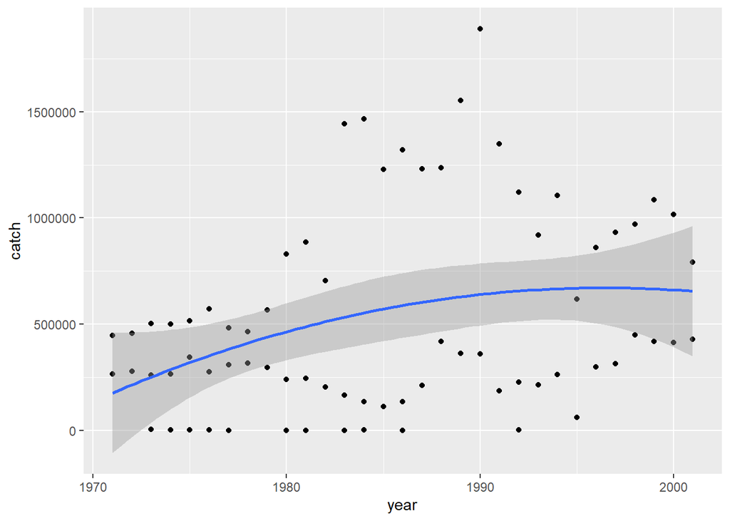

```r
?geom_smooth() # This one creates the linear model fit

ggplot(data=whitefish, aes(x = year, y = catch)) +
  geom_point() +
  geom_smooth(span=100)
```

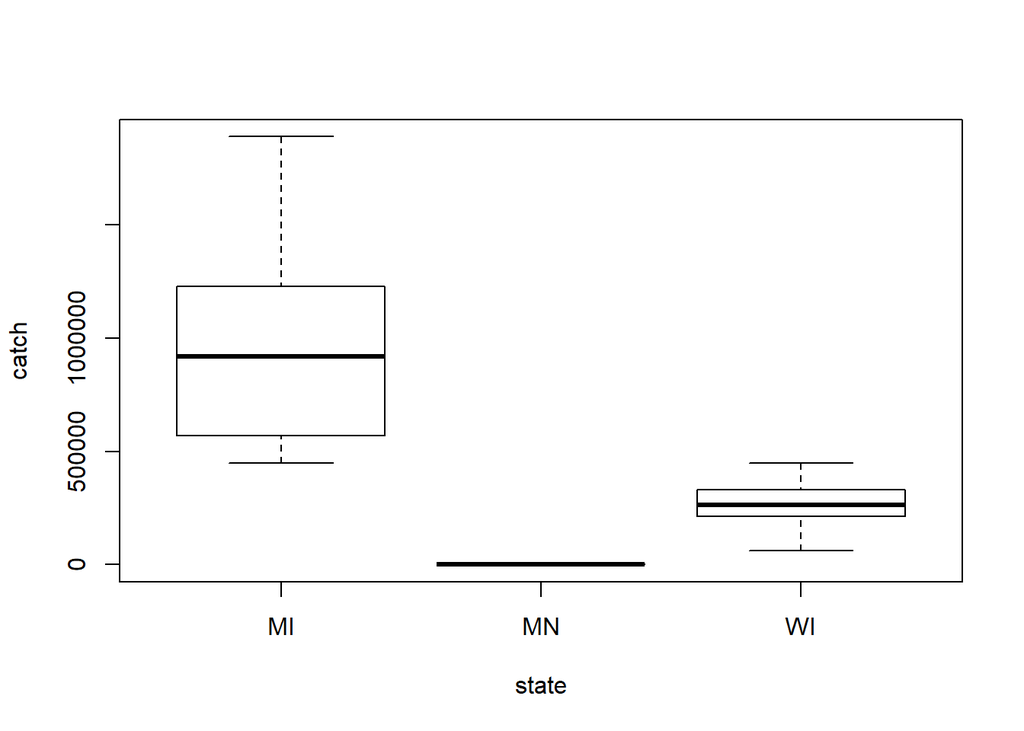

```r
# Loess smoothing is a process by which many statistical softwares do smoothing

# -------------------------------
# Discrete X, continuous Y

# Recall in base plot this will return a boxplot
plot(catch ~ state, data=whitefish)
```

```r
# In ggplot 'geom_boxplot()' would achieve this
ggplot(data=whitefish, aes(x = state, y = catch)) +
  geom_boxplot()
```

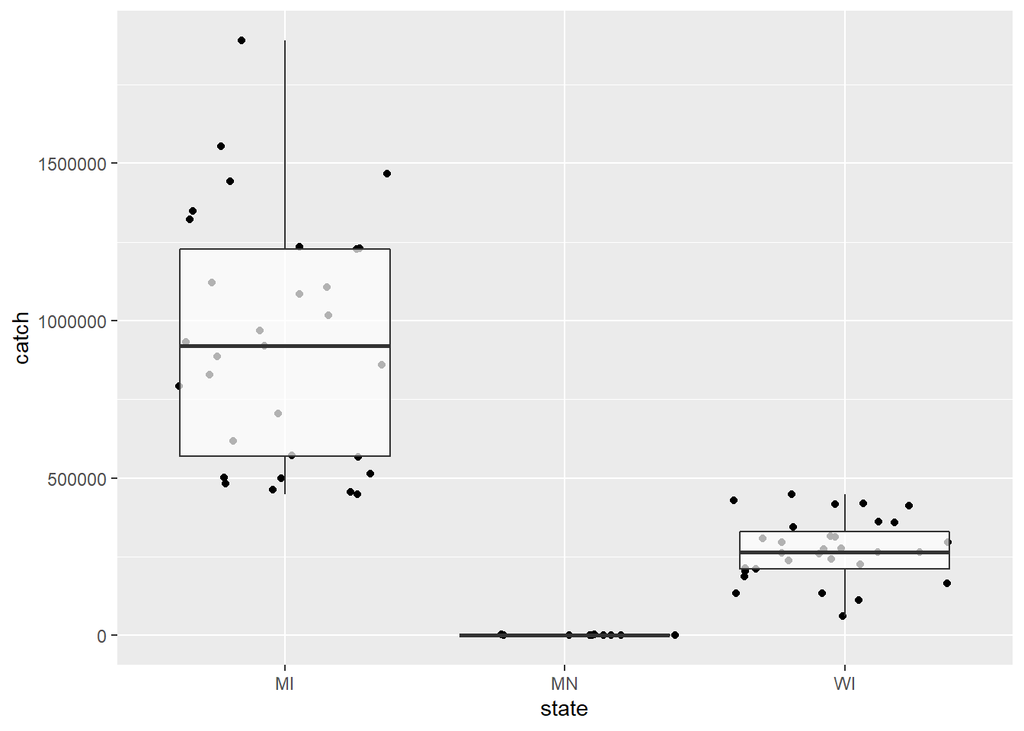

```r
# Adding datapoints may reveal some pattern not easy to see in a whiskerplot
ggplot(data=whitefish, aes(x = state, y = catch)) +
  geom_jitter() + # This prevents data points from overlapping
  geom_boxplot(alpha=0.7)
```

```r
a <- ggplot(data=whitefish, aes(x = state, y = catch))

a + geom_boxplot()
```

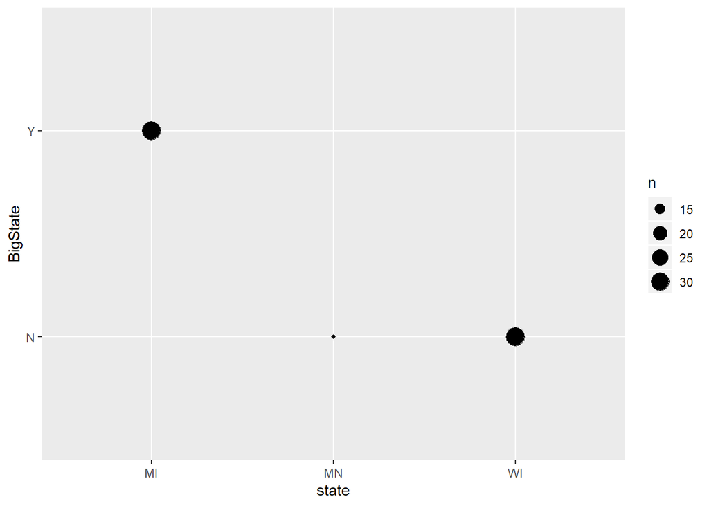

```r
# -------------------------------
# Discrete X vs. discrete Y

whitefish <- whitefish %>%
  mutate(BigState = ifelse(state=="MI", "Y", "N"))


ggplot(data=whitefish, aes(x=state, y = BigState)) +
  geom_count()
```

# Week 6

Daniel Gonzalez-Suarez

3/3/2020

# Introduction

Here we will explore how to create basic plots in R. To acknowledge my forebears, much of the material on this week’s class is based on a course in R by Dr. Brett Favaro.

Read the file WhitefishLS.csv into R These data are derived from Derek Ogle’s FSA data resources: http://derekogle.com/fishR/data/data-html/WhitefishLS.html

> > > Whitefish example, Variables are: year: Year of catch. state: State of catch (MI, MN, or WI). catch: Catch in lbs. value: Value of catch in dollars.

# Install required packages

```r
# If you don't yet have tidyverse run:
# install.packages("tidyverse")
library(tidyverse)

# We will require this package to handle some dates in this dataset
# install.packages("lubridate")
library(lubridate)
```

#Load data: Remember to check if it loaded & if data types are correct

```r
whitefish <- read.csv("./data/WhitefishLS.csv")

# ------------------------------------------
#STEP 1: Did it load correctly?
  head(whitefish)
```

```
##   year state  catch  value
## 1 1971    MI 447564 229001
## 2 1971    WI 264009 110540
## 3 1972    MI 455631 250860
## 4 1972    WI 277295 133918
## 5 1973    MI 501436 301909
## 6 1973    MN   3064   1568
```

```r
# ------------------------------------------
#STEP 2: Are the data types right?
  sapply(whitefish, class)
```

```
##      year     state     catch     value
## "integer"  "factor" "integer" "integer"
```

```r
#appears fine, except we have a date-type variable here.

# We will use the lubridate::date_decimal
# It tells R this is a date not a number
whitefish$year <- date_decimal(whitefish$year)

sapply(whitefish, class)
```

```
## $year
## [1] "POSIXct" "POSIXt"
##
## $state
## [1] "factor"
##
## $catch
## [1] "integer"
##
## $value
## [1] "integer"
```

```r
# We will explore some other functions of lubridate later

# ------------------------------------------
# STEP 3: Check for missing or impossible values

range(whitefish$year) #It now lines up with http://derekogle.com/fishR/data/data-html/WhitefishLS.html
```

```
## [1] "1971-01-01 UTC" "2001-01-01 UTC"
```

```r
range(whitefish$catch) #nothing jumps out as wrong. I guess it's a big fishery
```

```
## [1]       2 1890271
```

```r
plot(whitefish$catch)
```

```r
range(whitefish$value) #nothing impossible
```

```
## [1]       0 1748145
```

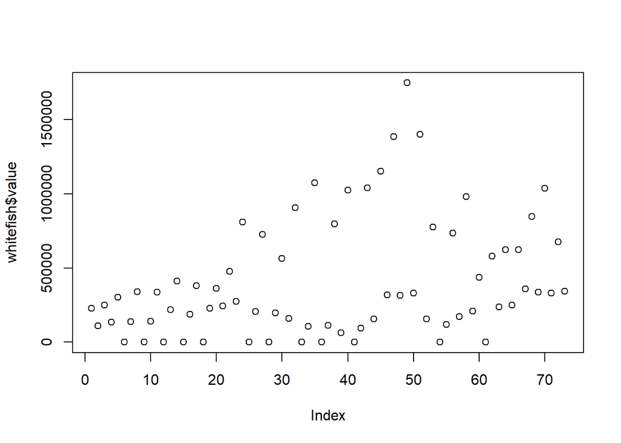

```r
plot(whitefish$value)
```

```r
# ------------------------------------------
# STEP 4: Factor levels

levels(whitefish$state)
```

```
## [1] "MI" "MN" "WI"
```

```r
# All seems to be OK!

# Let's move on to plotting!
```

# Plot One Variable - Base

```r
plot(whitefish$catch ~ whitefish$state)
```

```r
# One variable, X = Discrete (states)
# Y can only be count (catch)

table(whitefish$state)
```

```
##
## MI MN WI
## 31 11 31
```

```r
#Here 'table' creates a contingency table of the counts of each factor in a specific variable, in this case the number of times a state is mentioned
?table
```

```
## starting httpd help server ... done
```

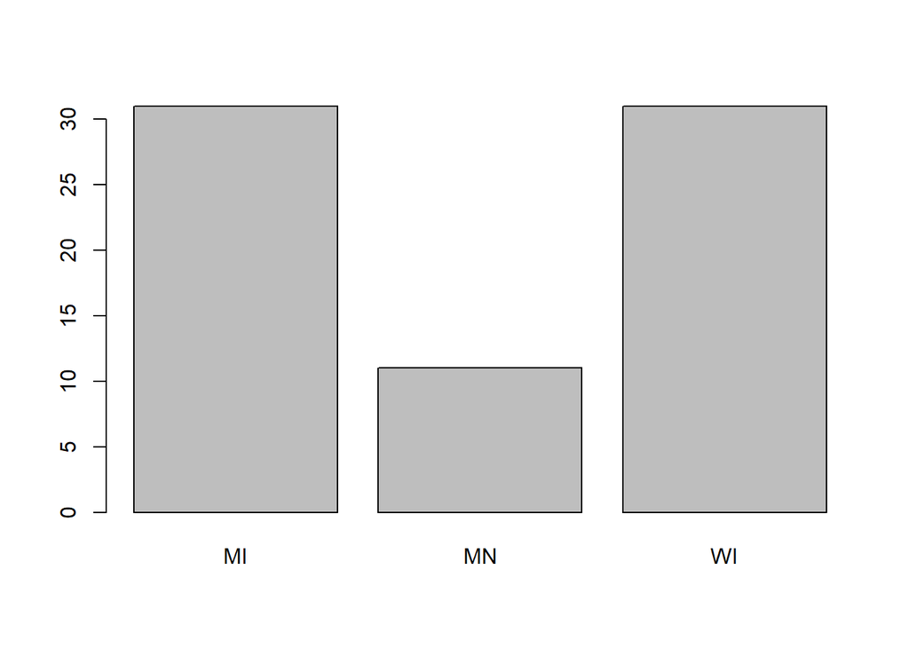

```r
barplot(table(whitefish$state))
```

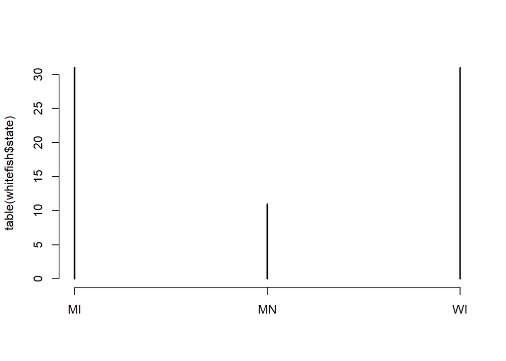

```r
plot(table(whitefish$state))
```

```r
# PLOT ONE VARIABLE
# Continuous X

plot(whitefish$catch)
```

```r
# No, this does not work

hist(whitefish$catch)
# Yes, this looks much better

?hist

# We can chose different breaks or bins of data
hist(whitefish$catch, breaks=10)
```

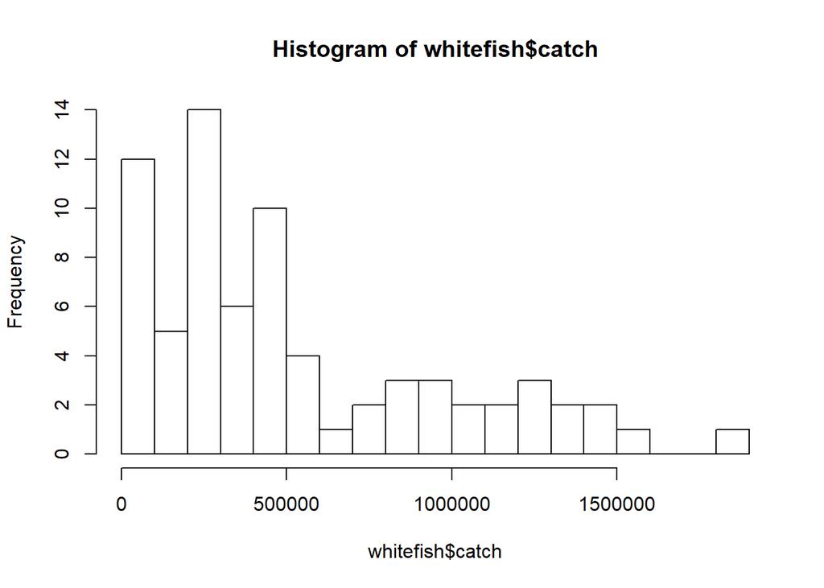

```r
hist(whitefish$catch, breaks=20)
```

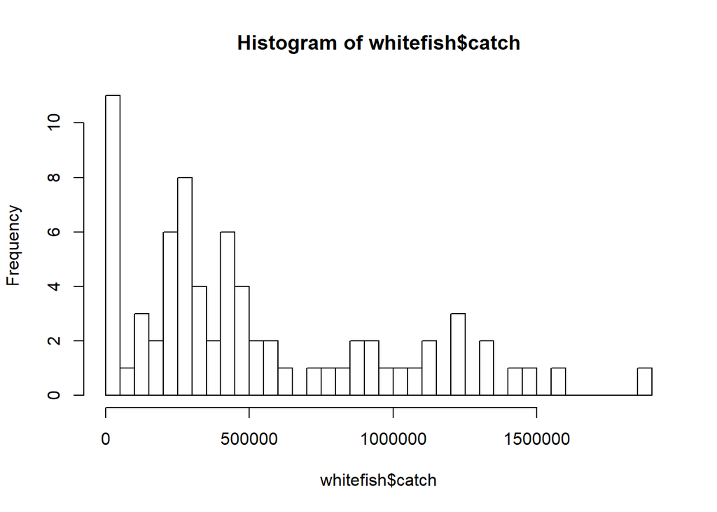

```r
hist(whitefish$catch, breaks=30)
```